# Plot Raster Data

**Objectives**

**keypoints**

- Continuous data ranges can be grouped into categories using `mutate()` and `cut()`.
- Use built-in `terrain.colors()` or set your preferred color scheme manually.

If you’re just opening up this project, you’ll have to load the packages and data used in previous episodes.

```r
# load packages
library(raster)
library(rgdal)
library(ggplot2)
library(dplyr)


# data loaded from earlier episode
# DSM data for Harvard Forest
dsm <- raster("data/raster/HARV_dsmCrop.tif")
dsm_df <- as.data.frame(dsm, xy = TRUE)
```

# Break up continuous data

In the previous episode, we viewed our data using a continuous color ramp. For clarity and visibility of the plot, we may prefer to view the data “symbolized” or colored according to ranges of values. This is comparable to a “classified” map. To do this, we need to tell `ggplot` how many groups to break our data into, and where those breaks should be. To make these decisions, it is useful to first explore the distribution of the data using a bar plot. To begin with, we will use `dplyr`’s `mutate()` function combined with `cut()` to split the data into 3 bins.

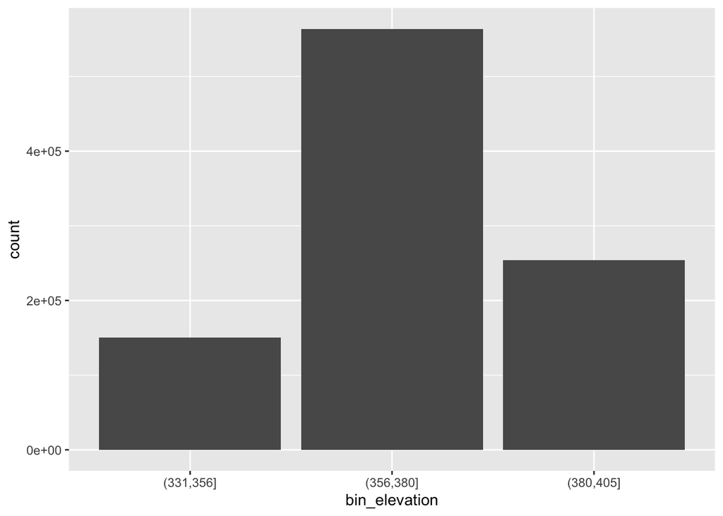

```r
# add column of binned elevation to df using mutate
# new column should break values into 3 bins using the cut function
dsm_df <- dsm_df %>%
                mutate(bin_elevation = cut(HARV_dsmCrop, breaks = 3))

# plot binned elevation with a bar chart
ggplot() +
    geom_bar(data = dsm_df, aes(bin_elevation))
```

# Use custom break values

We might prefer to customize the cutoff values for these groups. Lets round the cutoff values so that we have groups for the ranges of 301–350 m, 351–400 m, and 401–450 m. To implement this we will give `mutate()` a numeric vector of break points instead of the number of breaks we want.

```r
# create vector of bins values
custom_bins <- c(300, 350, 400, 450)

# use custom bins in cut function
dsm_df <- dsm_df %>%
  mutate(bin3_elevation = cut(HARV_dsmCrop, breaks = custom_bins))

# look at bin values
unique(dsm_df$bin3_elevation)
```

```
## [1] (350,400] (300,350] (400,450]
## Levels: (300,350] (350,400] (400,450]
```

And now we can plot our bar plot again, using the new groups:

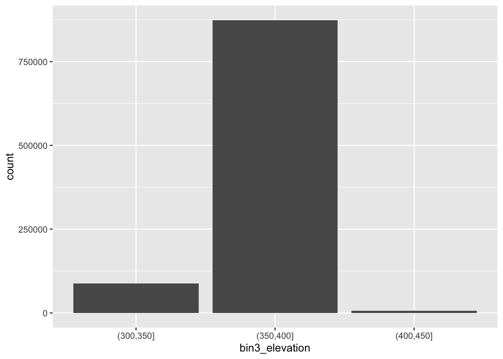

```r
# bar chart using custom bins
ggplot() +
  geom_bar(data = dsm_df, aes(bin3_elevation))
```

We can use those groups to plot our raster data, with each group being a different color:

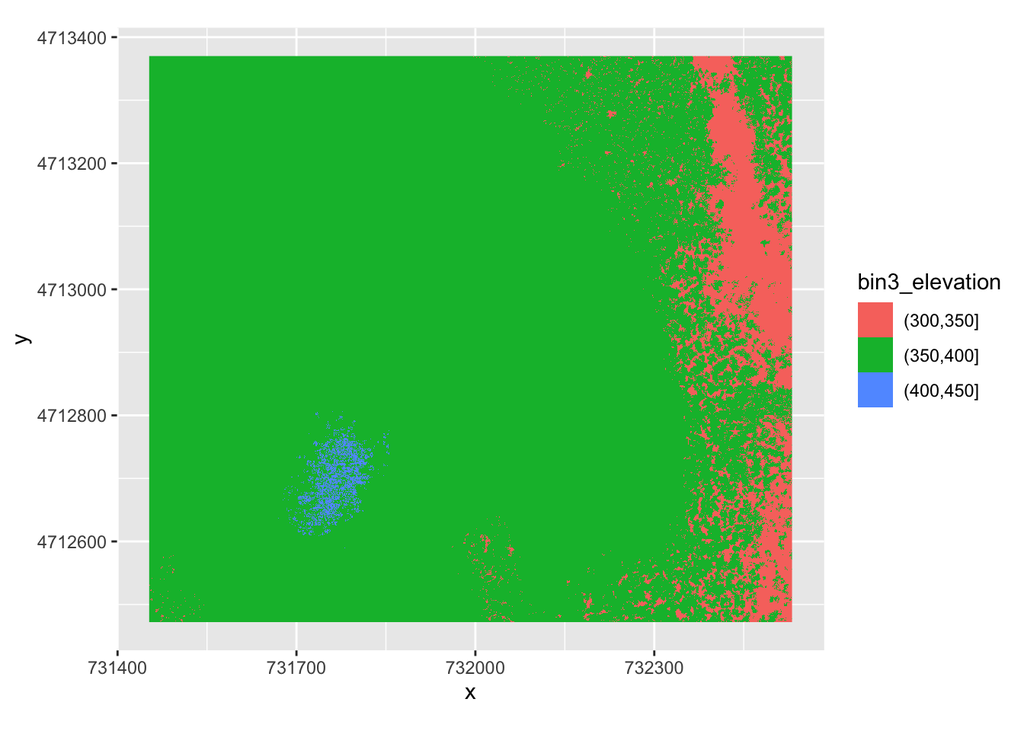

```r
ggplot() +
  geom_raster(data = dsm_df , aes(x = x, y = y, fill = bin3_elevation)) +
  coord_quickmap()
```

# Enhance plot with terrain colors

The plot above uses the default colors inside `ggplot` for raster objects. We can specify our own colors to make the plot look a little nicer. R has a built in set of colors for plotting terrain, which are built in to the `terrain.colors()` function. Since we have three bins, we want to create a 3-color palette:

```r
# look at hex codes for colors
terrain.colors(3)
```

```
## [1] "#00A600" "#ECB176" "#F2F2F2"
```

The `terrain.colors()` function returns *hex colors* - each of these character strings represents a color. To use these in our map, we pass them across using the `scale_fill_manual()` function.

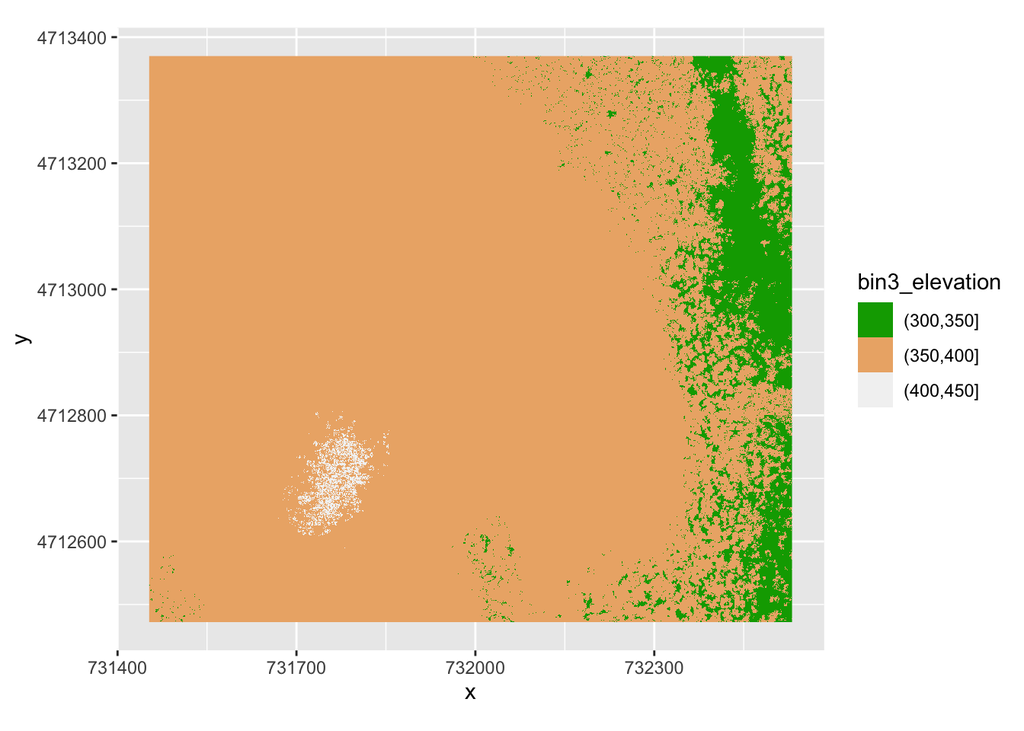

```r
# plor binned elevation using terrain colors
ggplot() +
 geom_raster(data = dsm_df , aes(x = x, y = y,
                                      fill = bin3_elevation)) +
    scale_fill_manual(values = terrain.colors(3)) +
    coord_quickmap()
```

We can continue to enhance this plot by adding more bins or classes of elevation data and adding other plot elements, such as a title and axis labels. Let’s break up the elevation data into 6 classes and add some helpful plot elements.

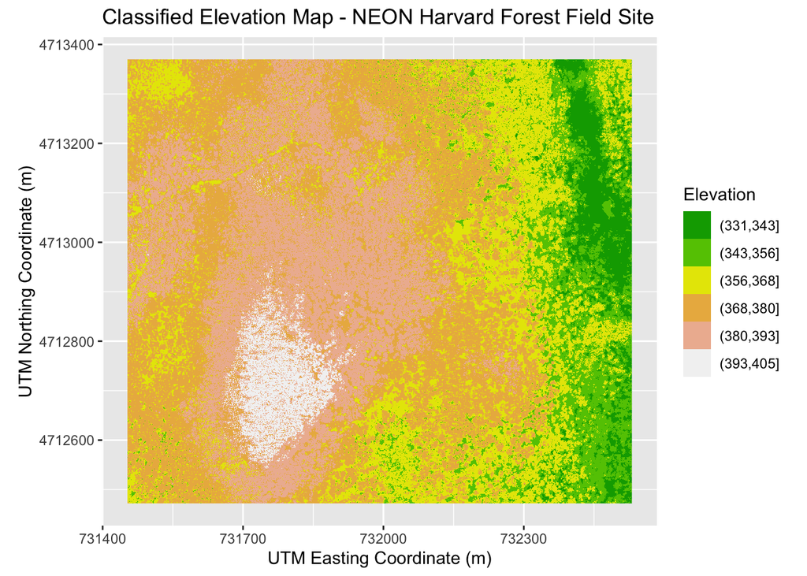

```r
dsm_df <- dsm_df  %>%
               mutate(bin6_elevation = cut(HARV_dsmCrop, breaks = 6))

# plot
ggplot() +
    geom_raster(data = dsm_df , aes(x = x, y = y,
                                      fill = bin6_elevation)) +
    scale_fill_manual(values = terrain.colors(6), name = "Elevation") +
    ggtitle("Classified Elevation Map - NEON Harvard Forest Field Site") +
    xlab("UTM Easting Coordinate (m)") +
    ylab("UTM Northing Coordinate (m)") +
    coord_quickmap()
```

The material has been adapted from The Carpentries [Introduction to Geospatial Raster and Vector Data with R](https://datacarpentry.org/r-raster-vector-geospatial/01-raster-structure/index.html) lesson licensed under [CC-BY 4.0](https://creativecommons.org/licenses/by/4.0/)